# Day 2 : Exploratory Data Analysis

包妹

2019-08-19

> 本日重點：用第一天學到的資料選取技巧，運用視覺化、基本的統計等工具，來「看」一下房價資料，哪些欄位重要。

```r
##設定環境
#setwd(dir) #設定working directory的存放位置
# MAC : setwd("/Users/rladiestaipei/R_DragonBall/")
# Windows : setwd("C://Users/rladiestaipei/Desktop/R_DragonBall/")

#安裝套件(僅需執行一次)
#install.packages(c("tidyverse", "ploty", "zoo", "lubridate", "rmarkdown","data.table", "DT", "kableExtra"), dependencies = TRUE)

#load packages
library(tidyverse)
library(ggplot2)
library(dplyr)
library(magrittr)
library(corrplot)
library(gridExtra)
library(plotly)
options(dplyr.print_max=1e9)
```

## Part 1 : load data and split

- 從第一天我們得知，共有 1460 個房子的資料，81 個欄位。
- 請搭配資料集介紹服用 [link](https://github.com/rladiestaipei/R_DragonBall/blob/master/R_DragonBall_Dataset.pdf)
- 通常欄位這麼多，看得眼花撩亂，可以先區分 `資料特性` 開始進行，資料特性大致上分下列幾種：
  - Qualitative(定性)/Categorical(類別)：無法計算，例如會員等級。
  - Quantitative(定量)/Numenical(數字型)：可以計算，例如金錢。
  - Discrete Data(離散型資料)：經由計數的方法取得資料，例如班上有多少人。
  - Continuous Data(連續型資料)：經由量測的方法取得資料，例如溫度。

```r
# 讀取資料
train0 <- read.csv("train.csv", stringsAsFactors = FALSE)
test0 <- read.csv("test.csv", stringsAsFactors = FALSE)

# 分割 numeric and character 欄位
num_features <- names(which(sapply(train0, is.numeric)))
cat_features <- names(which(sapply(train0, is.character)))
train_numeric <- train0[, names(train0) %in% num_features]
train_categoric <- train0[, names(train0) %in% cat_features]

print(num_features)
```

```
 [1] "Id"            "MSSubClass"    "LotFrontage"   "LotArea"       "OverallQual"   "OverallCond"
 [7] "YearBuilt"     "YearRemodAdd"  "MasVnrArea"    "BsmtFinSF1"    "BsmtFinSF2"    "BsmtUnfSF"
[13] "TotalBsmtSF"   "X1stFlrSF"     "X2ndFlrSF"     "LowQualFinSF"  "GrLivArea"     "BsmtFullBath"
[19] "BsmtHalfBath"  "FullBath"      "HalfBath"      "BedroomAbvGr"  "KitchenAbvGr"  "TotRmsAbvGrd"
[25] "Fireplaces"    "GarageYrBlt"   "GarageCars"    "GarageArea"    "WoodDeckSF"    "OpenPorchSF"
[31] "EnclosedPorch" "X3SsnPorch"    "ScreenPorch"   "PoolArea"      "MiscVal"       "MoSold"
[37] "YrSold"        "SalePrice"
```

```r
print(cat_features)
```

```
 [1] "MSZoning"      "Street"        "Alley"         "LotShape"      "LandContour"   "Utilities"
 [7] "LotConfig"     "LandSlope"     "Neighborhood"  "Condition1"    "Condition2"    "BldgType"
[13] "HouseStyle"    "RoofStyle"     "RoofMatl"      "Exterior1st"   "Exterior2nd"   "MasVnrType"
[19] "ExterQual"     "ExterCond"     "Foundation"    "BsmtQual"      "BsmtCond"      "BsmtExposure"
[25] "BsmtFinType1"  "BsmtFinType2"  "Heating"       "HeatingQC"     "CentralAir"    "Electrical"
[31] "KitchenQual"   "Functional"    "FireplaceQu"   "GarageType"    "GarageFinish"  "GarageQual"
[37] "GarageCond"    "PavedDrive"    "PoolQC"        "Fence"         "MiscFeature"   "SaleType"
[43] "SaleCondition"
```

- 用資料特性分割，資料欄位有 `36個欄位是數字` 、有 `43個欄位是類別` ，再加上 Id 和 SalePrice.

## Part 2 : 檢視 missing value

- 正式進入 EDA 之前，還有幾件事情很關鍵
  - 格式調整 : 是否有 `categorical` 的資料變成 `Numenical` ？
  - 填補缺值 or 異常值: `null` 或 `NA` 的數量有多少？方法有 3 種
    1. 視情況以中位數, Min, Max 或平均數填補(甚至有時會用 `NA` )
    2. 另建新的欄位
    3. 刪掉整欄
  - 經標準化 : 可以考量是否把 `連續型數值` 標準化，但需視後面的模型而定，通常 `Regression model` 有差，但是 `Tree-based model` 沒有差。(第三天的 Feature Engineering 會告訴你如何做，別急！)

```r
# 先看num_features的36個欄位
# MSSubClass(住宅類型)、OverallQual(材料與完成度評比)、OverallCond(綜合狀況評比) 很明確屬於factor，先轉換。
train0$OverallCond <- as.factor(train0$OverallCond)
train0$OverallQual <- as.factor(train0$OverallQual)
train0$MSSubClass <- as.factor(train0$MSSubClass)

# 查看每個欄位的缺失值和比例
missing_values <- sapply(train0, function(x) sum(is.na(x)))
null_count <- data.frame(Count = missing_values, Proportion = missing_values/nrow(train0))
null_count_gteZero <- null_count[null_count$Count > 0, ]
null_count_gteZero[order(-null_count_gteZero$Count),]
```

```
             Count   Proportion
PoolQC        1453 0.9952054795
MiscFeature   1406 0.9630136986
Alley         1369 0.9376712329
Fence         1179 0.8075342466
FireplaceQu    690 0.4726027397
LotFrontage    259 0.1773972603
GarageType      81 0.0554794521
GarageYrBlt     81 0.0554794521
GarageFinish    81 0.0554794521
GarageQual      81 0.0554794521
GarageCond      81 0.0554794521
BsmtExposure    38 0.0260273973
BsmtFinType2    38 0.0260273973
BsmtQual        37 0.0253424658
BsmtCond        37 0.0253424658
BsmtFinType1    37 0.0253424658
MasVnrType       8 0.0054794521
MasVnrArea       8 0.0054794521
Electrical       1 0.0006849315
```

```r
# 刪除所有出現NA的欄位
train_non_null <- train0 %>%
  select(-c(rownames(null_count_gteZero), OverallCond, OverallQual, MSSubClass))
```

## Part 3 : Various plots with SalePrice

### 3-1 : 檢視 Numenical 欄位與 SalePrice 關係

```r
# 先剔除出現NA的欄位，而且是數字的欄位
match_num_features <- paste(num_features, collapse = "|")
train_non_null_df <- select(train_non_null, matches(match_num_features))
```

> 學習用 `ggplot()` + `tidyr package` ，快速畫圖
- 以往大量畫不同變數的圖時，你可能會用 `for loop` + `par(mfrow = ...)` ，程式寫完、跑完，那一天大概也過完了。
- 但 `library(tidyr)` 的 `gather()`搭配`facet_wrap()`， 可以快速幫你解決這個問題(沒有業配XD)。他可以將欄位分成 `key` 跟 `value` 兩種。重新組合成一個 **長** 的格式，可以用 `key` 跟 `value` 選擇要保留下來的欄位。
- 另外，可使用 `library(purrr)` 的 `keep()` 選擇需要的變量。

> 示範用 `面積` 相關的欄位

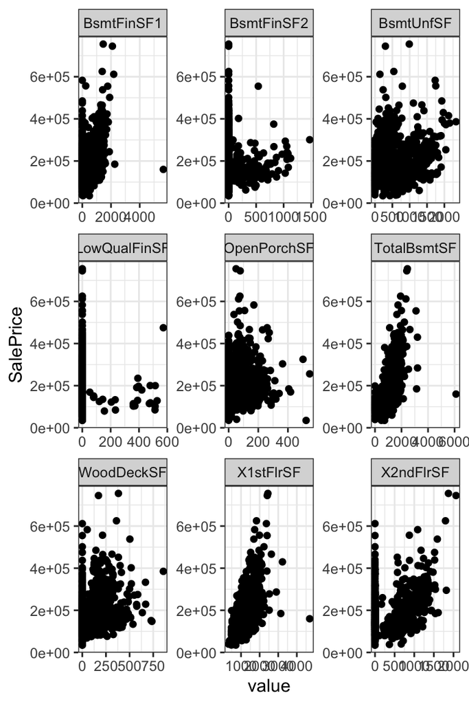

```r
theme_set(theme_bw())  # pre-set the bw theme.

# 篩選SF(面積)的欄位
train_SF <- select(train_non_null, matches("SF|SalePrice"))

# 各種面積與SalePrice的關係
train_SF %>%
  # keep(is.numeric) %>%
  gather(-SalePrice, key = "var", value = "value") %>%
  ggplot(aes(x = value, y = SalePrice)) +   # Plot the values
    facet_wrap(~ var, scales = "free") +   # In separate panels
    geom_point()
```

> 示範用 `時間` 相關的欄位

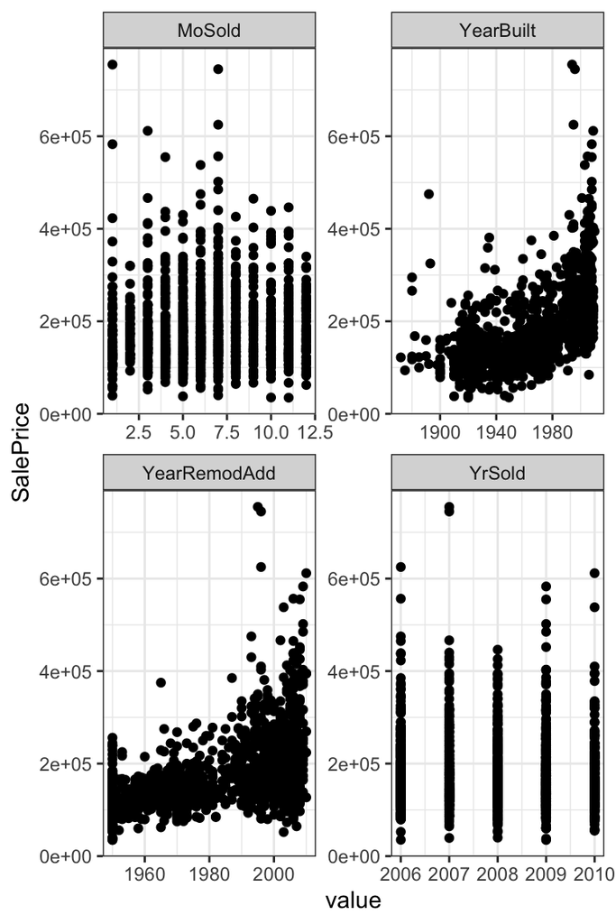

```r
# 篩選SF(面積)的欄位
train_Time <- select(train_non_null, matches("Yr|Year|Mo|year|yr|SalePrice"))

train_Time %>%
gather(-SalePrice, key = "var", value = "value") %>%
  ggplot(aes(x = value, y = SalePrice)) +   # Plot the values
    facet_wrap(~ var, scales = "free") +   # In separate panels
    geom_point()
```

> 示範用 `區域空間` 相關的欄位

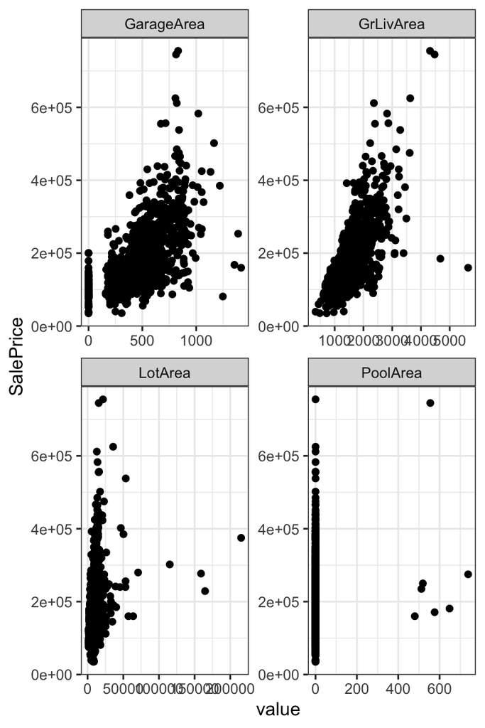

```r
# 篩選Area(區域空間)的欄位
train_Area <- select(train_non_null, matches("Area|SalePrice"))

train_Area %>%
gather(-SalePrice, key = "var", value = "value") %>%
  ggplot(aes(x = value, y = SalePrice)) +   # Plot the values
    facet_wrap(~ var, scales = "free") +   # In separate panels
    geom_point()
```

- 依照上述，可以大致選擇 `feature` 候選人: `X1stFlrSF` , `TotalBsmtSF` , `YearBuilt` , `GrLivArea` , `LotArea` 。

### 3-2 : 檢視 Categorical 欄位與 SalePrice 關係

```r
# 先剔除出現NA的欄位，而且是數字的欄位
match_cat_features <- paste(cat_features, collapse = "|")
train_non_null_df <- select(train_non_null, matches(match_num_features))
```

> 示範用 `房屋外觀` 相關的欄位

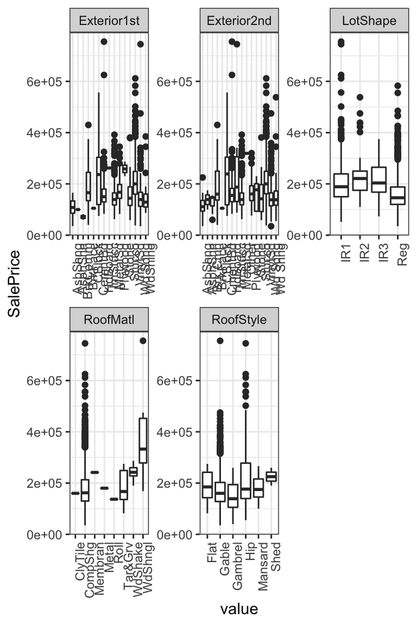

```r
# 篩選房屋外觀的欄位
train_outside <- select(train_non_null, matches("Roof|MSSubClass|LotShape|Exterior|SalePrice"))

# 各種房屋外觀與SalePrice的關係
train_outside %>%
  gather(-SalePrice, key = "var", value = "value") %>%
  ggplot(aes(x = value, y = SalePrice)) +   # Plot the values
    facet_wrap(~ var, scales = "free") +   # In separate panels
    geom_boxplot(na.rm = T) +
    theme(axis.text.x = element_text(angle = 90, hjust = 1))
```

> 示範用 `房屋內部` 相關的欄位

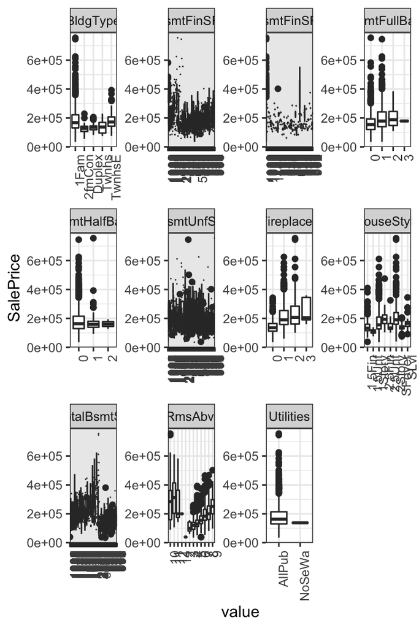

```r
# 篩選房屋內部的欄位
train_inside <- select(train_non_null, matches("BldgType|Utilities|House|Bsmt|TotRmsAbvGrd|Fireplace|SalePrice"))

train_inside %>%
gather(-SalePrice, key = "var", value = "value") %>%
  ggplot(aes(x = value, y = SalePrice)) +   # Plot the values
    facet_wrap(~ var, scales = "free") +   # In separate panels
    geom_boxplot(na.rm = T) +
    theme(axis.text.x = element_text(angle = 90, hjust = 1))
```

> 示範用 `其他空間` 相關的欄位

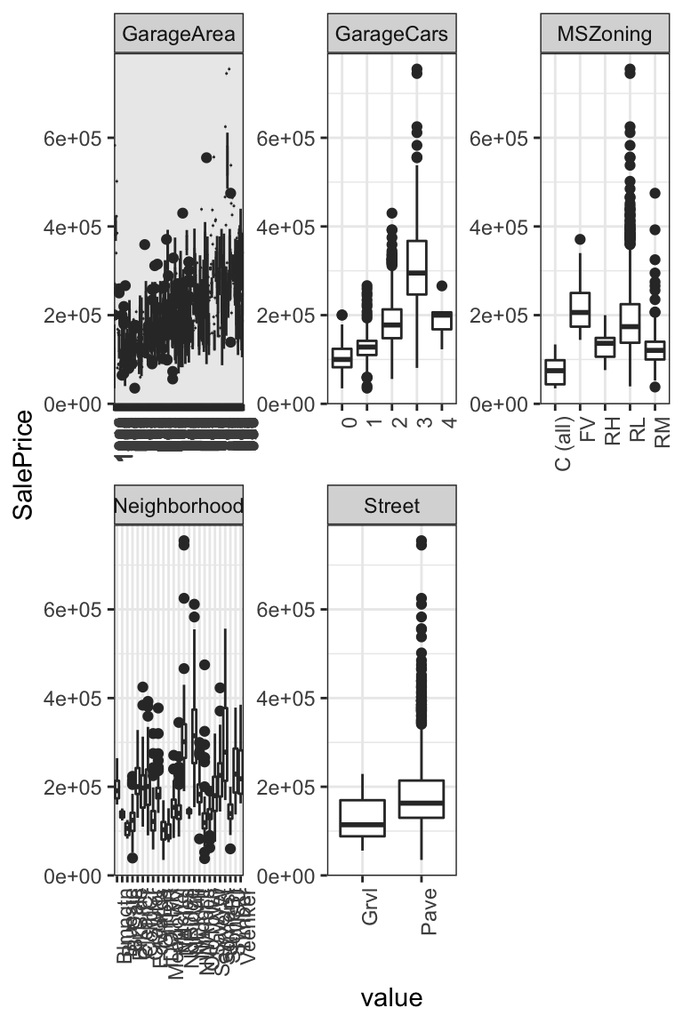

```r
# 篩選Area(區域空間)的欄位
train_other <- select(train_non_null, matches("Electrical|Neighborhood|Street|Garage|MSZoning|SalePrice"))

train_other %>%
gather(-SalePrice, key = "var", value = "value") %>%
  ggplot(aes(x = value, y = SalePrice)) +   # Plot the values
    facet_wrap(~ var, scales = "free") +   # In separate panels
    geom_boxplot(na.rm = T) +
    theme(axis.text.x = element_text(angle = 90, hjust = 1))
```

### 3-3 小練習 : 換你來試找其他欄位的特徵

## Part 4 : Correlations

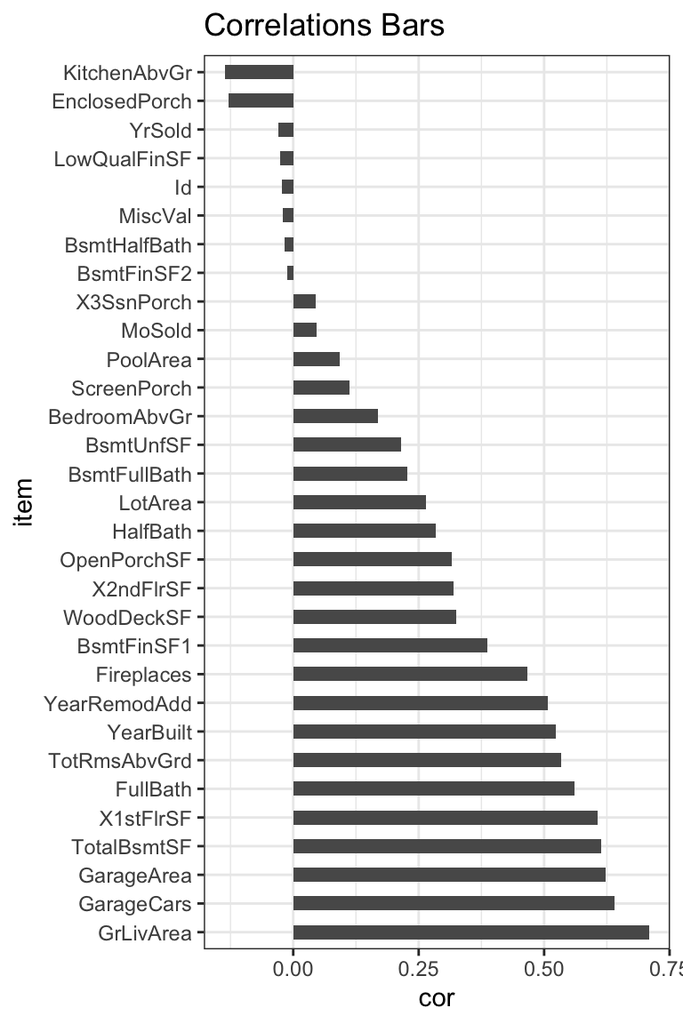

```r
correlations <- cor(train_non_null_df, use = "complete.obs")
cor_bar <- data.frame("cor" = correlations[,"SalePrice"])
cor_bar$item <- row.names(cor_bar)
cor_bar <- cor_bar[order(-cor_bar$cor),][-1,]
cor_bar$item <- factor(cor_bar$item, levels=cor_bar$item)

ggplot(cor_bar) +
  geom_bar(stat='identity', aes(x = item, y = cor), width=.5)  +
  labs(title= "Correlations Bars") +
  coord_flip()
```

- 相關係數前三名為 `GrLivArea: 0.71` , `GarageCars: 0.64` , `GarageArea: 0.62`。

## Part 5 : 檢視 SalePrice 分布

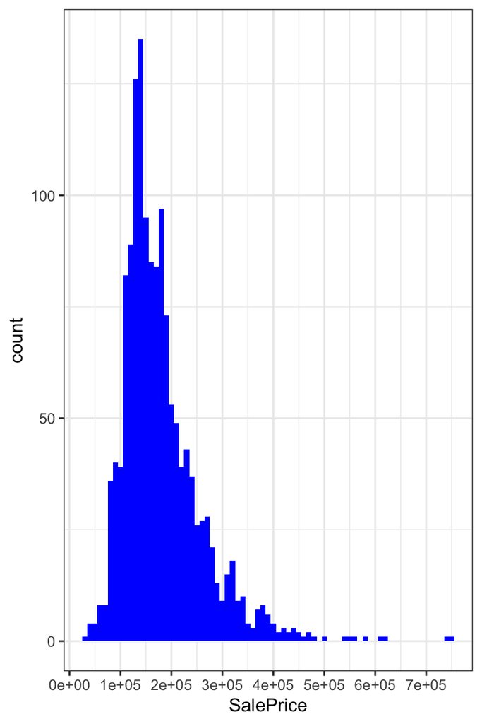

```
   Min. 1st Qu.  Median    Mean 3rd Qu.    Max.
  34900  129975  163000  180921  214000  755000
```

- 明顯的右偏態，我們把它轉換一下，取 `log()` 後對模型訓練也許有幫助。

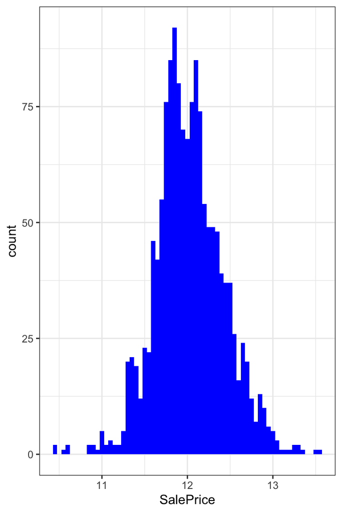

```
   Min. 1st Qu.  Median    Mean 3rd Qu.    Max.
  10.46   11.78   12.00   12.02   12.27   13.53
```

## 本日小挑戰

> 請挑選 training data 中你覺得其他重要的欄位，和房價有什麼關係。